# Week 2 Peer Review

Your objective is to replicate these figures, created using the Cooperative Congressional Election Study data. These figures are similar to those we completed in the lecture videos.

### Put your name here: Iqman Singh Bhatia

## Exercise 1

Hints:

- For the x-axis, use the variable “ideo5”.
- Make sure you recode the data for the “ideo5” variable to generate the correct names for the x-axis. You will want to consult the codebook.
- Use the fill aesthetic to have R fill in the bars. You do not need to set the colors manually.
- Use guides() to drop the legend.
- Make sure the axis labels and figure title are correct.

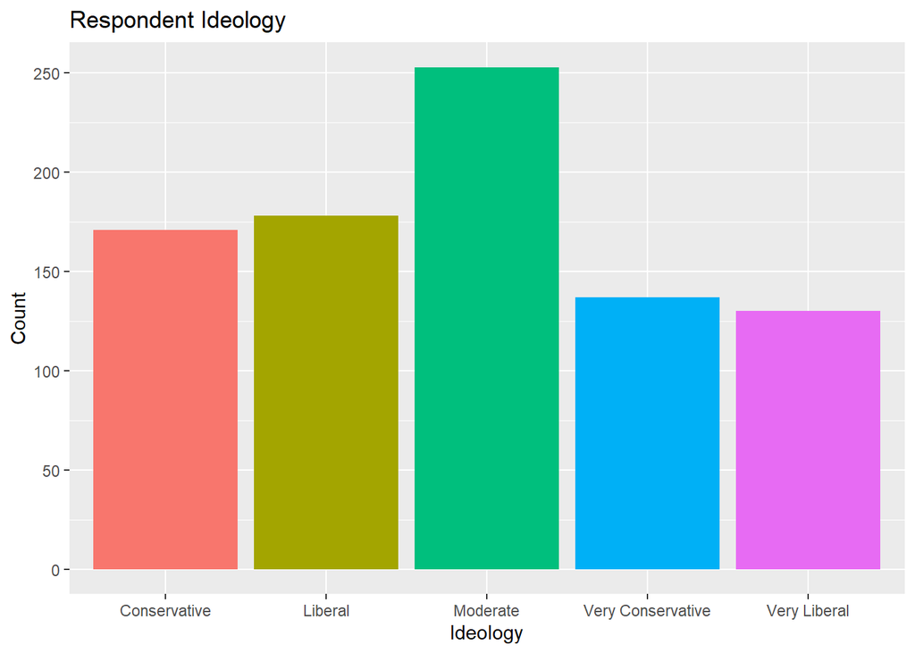

```r
cces$ideo5 = recode(cces$ideo5,
                    `1` = "Very Liberal",
                    `2` = "Liberal",
                    `3` = "Moderate",
                    `4` = "Conservative",
                    `5` = "Very Conservative")
ggplot(cces, aes(x=ideo5,fill=ideo5)) + geom_bar() + guides(fill="none") + labs(title="Respondent Ideology", x ="Ideology", y = "Count")
```

## Exercise 2

Hints:

- For the x-axis, use the variable “pew_religimp”.
- Make sure you recode the data for the “pew_religimp” variable to generate the correct labels for the x-axis. You will want to consult the codebook.
- Rename the column for Ideology to make sure the first letter is upper-case (to make the legend appear correctly).
- Use the fill aesthetic to have R fill in the bars. You do not need to set the colors manually.
- Make sure the axis labels and figure title are correct.

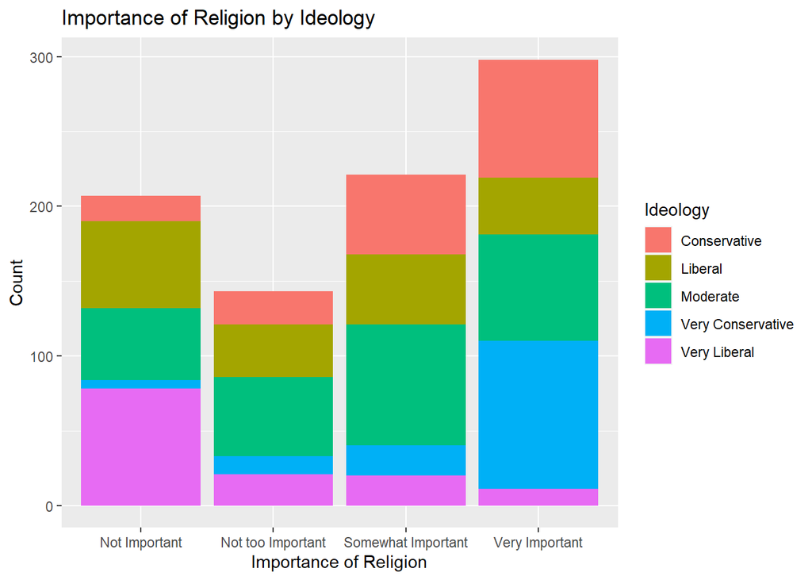

```r
cces$pew_religimp = recode(cces$pew_religimp,
                    `1` = "Very Important",
                    `2` = "Somewhat Important",
                    `3` = "Not too Important",
                    `4` = "Not Important")
ggplot(cces, aes(x=pew_religimp,fill=ideo5)) + geom_bar() + labs(title="Importance of Religion by Ideology", x ="Importance of Religion", y = "Count") + guides(fill=guide_legend(title="Ideology"))
```

## Exercise 3

Instructions:

- For this visualization, you are creating your own data for practice.
- Create a tibble/data frame with three columns: Semester, Student, and Grade.
- There should be six semesters and three students (Amanda, Betty, and Carol)
- Create grades for the students using the runif() command, with values between 80 and 100. Hint: you’ll need 18 grades total.

The figure should look approximately like this (your vaules will be slightly different):

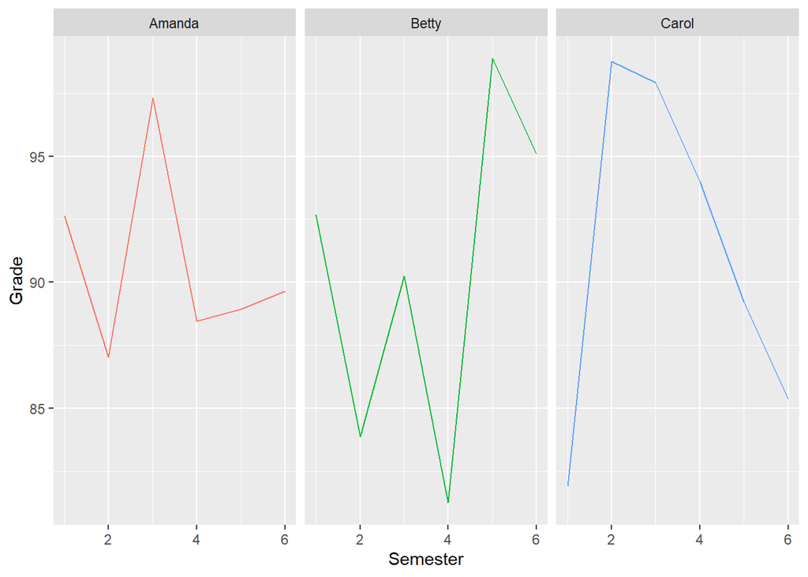

```r
Semester = rep(c(1:6),3)
Student = c(rep("Amanda",6),rep("Betty",6),rep("Carol",6))
Grade = runif(n = 18,min=80,max=100)
df = data.frame(Semester,Student,Grade)
ggplot(data=df, aes(x=Semester, y=Grade,fill=T)) + geom_line(aes(color=Student))+ facet_grid(cols = vars(Student)) + guides(col ="none")
```